# ISLR Chapter 8 - applied

## Exercise 7

**In the lab, we applied random forests to the Boston data using `mtry=6` and using `ntree=25` and `ntree=500`. Create a plot displaying the test error resulting from random forests on this data set for a more comprehensive range of values for `mtry` and `ntree`. You can model your plot after Figure 8.10. Describe the results obtained.**

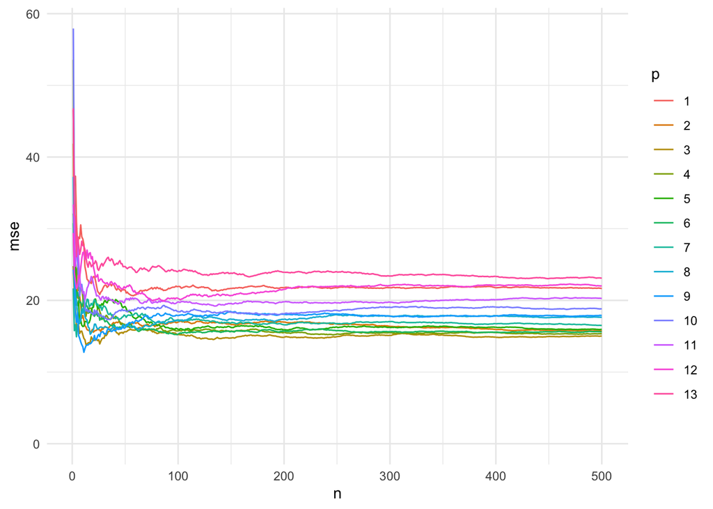

```r
# Create training data set
set.seed(1)
p <- ncol(Boston) - 1
train_idx <- sample(seq_len(nrow(Boston)), 0.7 * nrow(Boston))

# Create function to fit random forest model at various numbers of predictors and trees
fit_rf <- function(p = NULL, n = 500, data, train_idx, response_name) {
  if (is.null(p)) {
    p <- round((ncol(data) - 1) / 3)
  }
  randomForest(x = data[train_idx, which(names(data) != response_name)],
               y = data[train_idx, response_name],
               xtest = data[-train_idx, which(names(data) != response_name)],
               ytest = data[-train_idx, response_name],
               mtry = p,
               ntree = n)
}

# Loop through numbers of predictors and trees
rfs <- lapply(seq_len(p),
              function(p) {
                fit_rf(p, 500,
                       data = Boston,
                       train_idx = train_idx,
                       response_name = "medv")
              })

# Construct data.frames for plotting function
mses_p <- lapply(seq_len(p), function(i) {
  data.frame(mse = rfs[[i]]$test$mse, p = i, n = 1:500)
})

mses_plot <- do.call(rbind, mses_p)
mses_plot$p <- as.factor(mses_plot$p)

# Create plot, colour coded by value of p across different ntree values
ggplot(data = mses_plot) +
  geom_line(aes(x = n, y = mse, colour = p)) +
  expand_limits(y = 0) +
  theme_minimal()
```

## Exercise 8

**In the lab, a classification tree was applied to the Carseats data set after converting Sales into a qualitative response variable. Now we will seek to predict Sales using regression trees and related approaches, treating the response as a quantitative variable.**

**Split the data set into a training set and a test set.**

```r
set.seed(123)
train_idx <- sample(seq_len(nrow(Carseats)),
                    nrow(Carseats) * 0.7)
train <- Carseats[train_idx,]
test <- Carseats[-train_idx,]
```

**Fit a regression tree to the training set. Plot the tree, and interpret the results. What test MSE do you obtain?**

```r
carseats_tree <- tree(Sales ~ . , data = train)
sprintf("Test MSE: %s", mean((predict(carseats_tree, test) - test$Sales) ^ 2))
```

```
## [1] "Test MSE: 3.60281802993858"
```

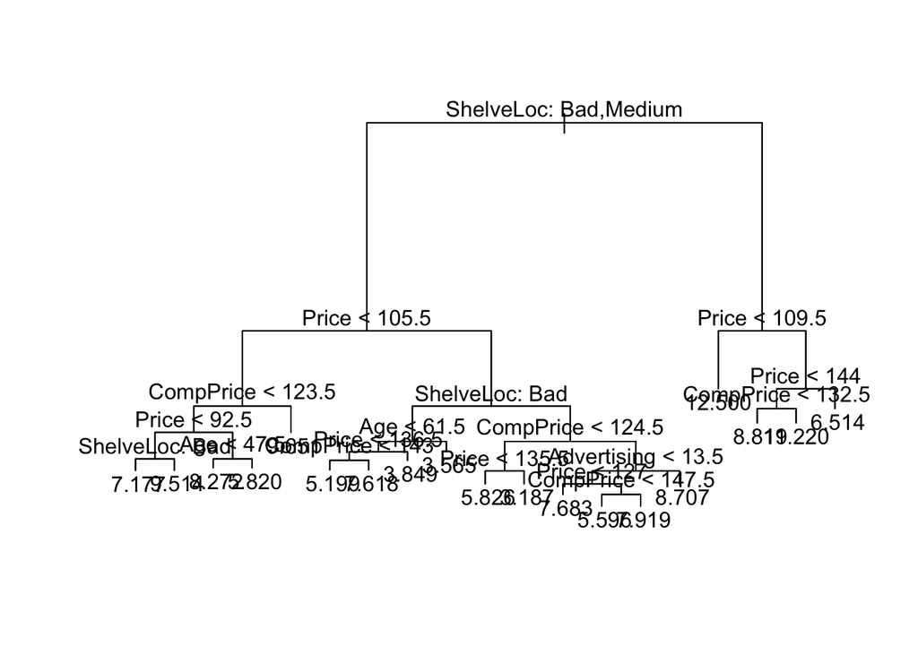

```r
plot(carseats_tree)
text(carseats_tree, pretty = 0)
```

**Use cross-validation in order to determine the optimal level of tree complexity. Does pruning the tree improve the test MSE?**

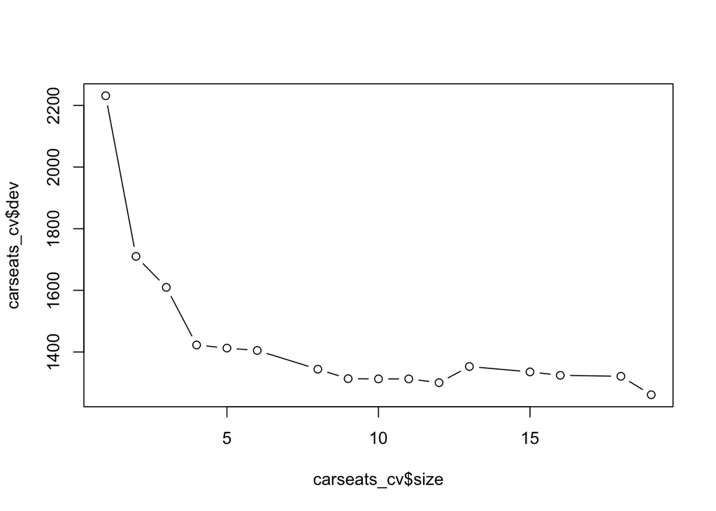

```r
carseats_cv <- cv.tree(carseats_tree)
plot(carseats_cv$size, carseats_cv$dev, type="b")
```

Pruning does not appear to improve model performance, as the most complex tree gives the best performing fit.

**Use the bagging approach in order to analyze this data. What test MSE do you obtain? Use the `importance()` function to determine which variables are most important.**

```r
m <- ncol(train) - 1
carseats_bag <- randomForest(Sales ~ ., data = train, mtry = m, importance = TRUE)
sprintf("Test MSE: %s", mean((predict(carseats_bag, test) - test$Sales) ^ 2))
```

```
## [1] "Test MSE: 2.27886543879615"
```

```r
importance(carseats_bag)
```

```
##                %IncMSE IncNodePurity
## CompPrice   35.7999670    262.298264
## Income       7.8716191    119.388933
## Advertising 20.8395402    152.464416
## Population   2.1760765     66.209944
## Price       63.0665019    621.449901
## ShelveLoc   72.4630954    685.134197
## Age         19.1347198    177.449419
## Education    4.3626732     66.736646
## Urban        0.3123883      9.295726
## US           1.3827536      7.787507
```

`ShelveLoc` and `Price` appear to be the most important variables. Test MSE has improved to 2.28.

**Use random forests to analyze this data. What test MSE do you obtain? Use the `importance()` function to determine which variables are most important. Describe the effect of m, the number of variables considered at each split, on the error rate obtained.**

```r
carseats_forest <- randomForest(Sales ~ ., data = train, importance = TRUE)
sprintf("Test MSE: %s", mean((predict(carseats_forest, test) - test$Sales) ^ 2))
```

```
## [1] "Test MSE: 2.70439916417327"
```

```r
importance(carseats_forest)
```

```
##                %IncMSE IncNodePurity
## CompPrice   16.7196294     230.02523
## Income       6.2625691     168.90108
## Advertising 16.2090797     183.37645
## Population  -1.3086954     129.80261
## Price       42.9458404     488.50809
## ShelveLoc   46.8917226     513.90664
## Age         17.9735745     257.21081
## Education    1.2049797     103.30595
## Urban        0.8486326      19.34474
## US           4.3444583      25.30593
```

`Price` and `ShelveLoc` are still the most important variables. Using the default value for `mtry` (p/3), test MSE is worse than the bagging model, at 2.70.

## Exercise 9

**This problem involves the `OJ` data set which is part of the `ISLR` package.**

**Create a training set containing a random sample of 800 observations, and a test set containing the remaining observations.**

```r
set.seed(1)
train_idx <- sample(nrow(OJ), 800)
train <- OJ[train_idx,]
test <- OJ[-train_idx,]
```

**Fit a tree to the training data, with `Purchase` as the response and the other variables as predictors. Use the `summary()` function to produce summary statistics about the tree, and describe the results obtained. What is the training error rate? How many terminal nodes does the tree have?**

```r
oj_tree <- tree(Purchase ~ ., data = train)
summary(oj_tree)
```

```
##
## Classification tree:
## tree(formula = Purchase ~ ., data = train)
## Variables actually used in tree construction:
## [1] "LoyalCH"       "PriceDiff"     "SpecialCH"     "ListPriceDiff"
## [5] "PctDiscMM"
## Number of terminal nodes:  9
## Residual mean deviance:  0.7432 = 587.8 / 791
## Misclassification error rate: 0.1588 = 127 / 800
```

The training error rate is 15.88%, and the tree has 9 terminal nodes. `LoyalCH`, `PriceDiff`, `SpecialCH`, `ListPriceDiff` and `PctDiscMM` are used in internal nodes in the tree. The residual mean deviance is reported as 0.7432.

**Type in the name of the tree object in order to get a detailed text output. Pick one of the terminal nodes, and interpret the information displayed.**

```r
oj_tree
```

```
## node), split, n, deviance, yval, (yprob)
##       * denotes terminal node
##
##  1) root 800 1073.00 CH ( 0.60625 0.39375 )
##    2) LoyalCH < 0.5036 365  441.60 MM ( 0.29315 0.70685 )
##      4) LoyalCH < 0.280875 177  140.50 MM ( 0.13559 0.86441 )
##        8) LoyalCH < 0.0356415 59   10.14 MM ( 0.01695 0.98305 ) *
##        9) LoyalCH > 0.0356415 118  116.40 MM ( 0.19492 0.80508 ) *
##      5) LoyalCH > 0.280875 188  258.00 MM ( 0.44149 0.55851 )
##       10) PriceDiff < 0.05 79   84.79 MM ( 0.22785 0.77215 )
##         20) SpecialCH < 0.5 64   51.98 MM ( 0.14062 0.85938 ) *
##         21) SpecialCH > 0.5 15   20.19 CH ( 0.60000 0.40000 ) *
##       11) PriceDiff > 0.05 109  147.00 CH ( 0.59633 0.40367 ) *
##    3) LoyalCH > 0.5036 435  337.90 CH ( 0.86897 0.13103 )
##      6) LoyalCH < 0.764572 174  201.00 CH ( 0.73563 0.26437 )
##       12) ListPriceDiff < 0.235 72   99.81 MM ( 0.50000 0.50000 )
##         24) PctDiscMM < 0.196196 55   73.14 CH ( 0.61818 0.38182 ) *
##         25) PctDiscMM > 0.196196 17   12.32 MM ( 0.11765 0.88235 ) *
##       13) ListPriceDiff > 0.235 102   65.43 CH ( 0.90196 0.09804 ) *
##      7) LoyalCH > 0.764572 261   91.20 CH ( 0.95785 0.04215 ) *
```

Picking node 9, the node splits the data where `LoyalCH` is greater than 0.0356415. The overall prediction at this node is `MM`, and 118 observations are considered at this node. About 81% of the observations are classified to `MM`. The asterisk indicates this is a terminal node.

**Create a plot of the tree, and interpret the results.**

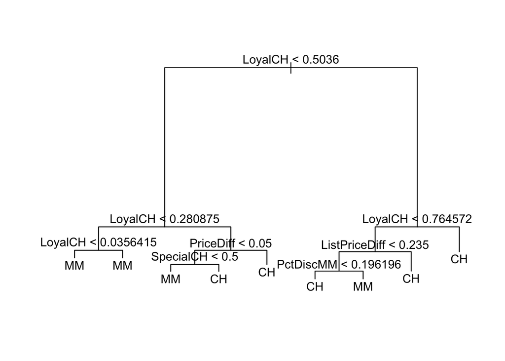

```r
plot(oj_tree)
text(oj_tree, pretty = 0)
```

`LoyalCH` is the variable that is most frequently considered at each node, being used at the first few splits, which suggests it is an important predictor. The points where other predictors are considered suggest that where `LoyalCH` is between 0.280875 and 0.5036, then if `Price Diff` is greater than 0.05, then predict `CH`, otherwise, if `Special CH` is greater than 0.5, then predict `CH`. In all other cases where `LoyalCH` is less than 0.5036, predict `MM`. Where `LoyalCH` is greater than 0.764572, predict `CH`. If it is not, then predict `CH` where `ListPriceDiff` is greater than 0.235, otherwise, predict `CH` where `PctDiscMM` is less than 0.196196. In all other cases, we predict `MM`.

**Predict the response on the test data, and produce a confusion matrix comparing the test labels to the predicted test labels. What is the test error rate?**

```r
oj_pred <- predict(oj_tree, test, type = "class")
table(oj_pred, test$Purchase)
```

```
##
## oj_pred  CH  MM
##      CH 160  38
##      MM   8  64
```

```r
sprintf("Test error rate: %s", 1 - mean(oj_pred == test$Purchase))
```

```
## [1] "Test error rate: 0.17037037037037"
```

**Apply the `cv.tree()` function to the training set in order to determine the optimal tree size.**

```r
oj_cv <- cv.tree(oj_tree, FUN = prune.misclass)
oj_cv
```

```
## $size
## [1] 9 8 7 4 2 1
##
## $dev
## [1] 150 150 149 158 172 315
##
## $k
## [1]       -Inf   0.000000   3.000000   4.333333  10.500000 151.000000
##
## $method
## [1] "misclass"
##
## attr(,"class")
## [1] "prune"         "tree.sequence"
```

**Produce a plot with tree size on the x-axis and cross-validated classification error rate on the y-axis.**

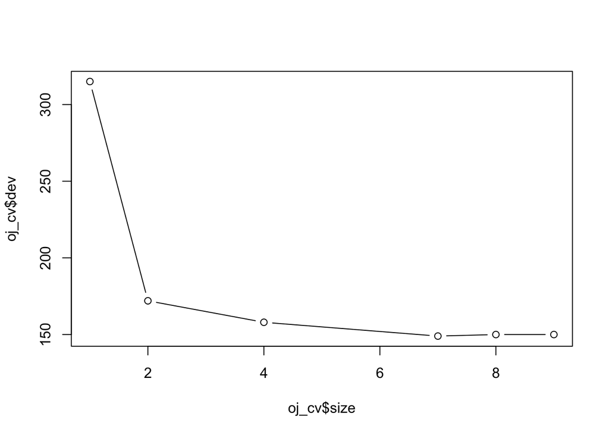

```r
plot(oj_cv$size, oj_cv$dev, type="b")
```

**Which tree size corresponds to the lowest cross-validated classification error rate?**

The optimal tree size is 7.

**Produce a pruned tree corresponding to the optimal tree size obtained using cross-validation. If cross-validation does not lead to selection of a pruned tree, then create a pruned tree with five terminal nodes.**

```r
oj_prune <- prune.tree(oj_tree, best = 7)
summary(oj_prune)
```

```
##
## Classification tree:
## snip.tree(tree = oj_tree, nodes = c(10L, 4L))
## Variables actually used in tree construction:
## [1] "LoyalCH"       "PriceDiff"     "ListPriceDiff" "PctDiscMM"
## Number of terminal nodes:  7
## Residual mean deviance:  0.7748 = 614.4 / 793
## Misclassification error rate: 0.1625 = 130 / 800
```

**Compare the training error rates between the pruned and un- pruned trees. Which is higher?**

The training error rate for the pruned tree is higher, at 16.25% versus 15.88% for unpruned tree.

**Compare the test error rates between the pruned and unpruned trees. Which is higher?**

```r
oj_prune_pred <- predict(oj_prune, test, type = "class")
table(oj_prune_pred, test$Purchase)
```

```
##
## oj_prune_pred  CH  MM
##            CH 160  36
##            MM   8  66
```

```r
sprintf("Test unpruned error rate: %s", 1 - mean(oj_pred == test$Purchase))
```

```
## [1] "Test unpruned error rate: 0.17037037037037"
```

```r
sprintf("Test pruned error rate: %s", 1 - mean(oj_prune_pred == test$Purchase))
```

```
## [1] "Test pruned error rate: 0.162962962962963"
```

The test error for the unpruned tree is higher, at 17.04% versus 16.30% for the pruned tree.

## Exercise 10

**We now use boosting to predict Salary in the Hitters data set.**

**Remove the observations for whom the salary information is unknown, and then log-transform the salaries.**

```r
hitters <- Hitters[!is.na(Hitters$Salary),]
hitters$Salary <- log(hitters$Salary)
```

**Create a training set consisting of the first 200 observations, and a test set consisting of the remaining observations.**

```r
set.seed(12345)
train <- hitters[1:200,]
test <- hitters[-c(1:200),]
```

**Perform boosting on the training set with 1,000 trees for a range of values of the shrinkage parameter $lambda$. Produce a plot with different shrinkage values on the x-axis and the corresponding training set MSE on the y-axis.**

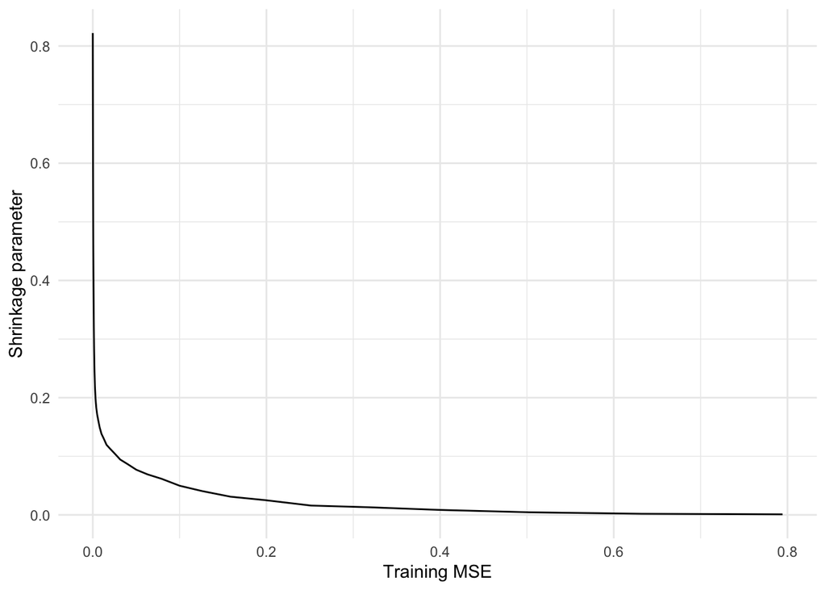

```r
lambdas <- sapply(seq(-5, -0.1, by = 0.1), function(x) 10^x)
gbm_list <- lapply(lambdas,
                  function(lambda) {
                    gbm(Salary ~ ., data = train, distribution = "gaussian", n.trees = 1000, shrinkage = lambda)
                  })
mses <- sapply(gbm_list, function(x) x$train.error[length(x$train.error)])
ggplot() +
  geom_line(aes(x = lambdas, y = mses)) +
  theme_minimal() +
  xlab("Training MSE") +
  ylab("Shrinkage parameter")
```

**Produce a plot with different shrinkage values on the x-axis and the corresponding test set MSE on the y-axis.**

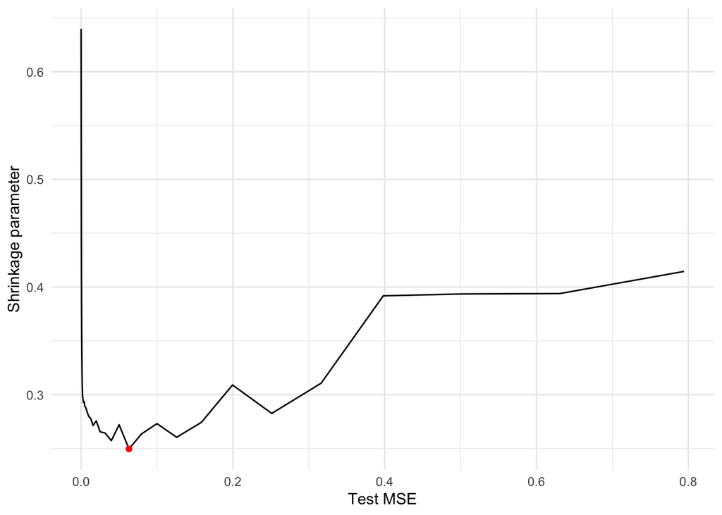

```r
test_mses <- sapply(gbm_list,
                    function(x) {
                      suppressMessages(
                        mean((predict(x, test) - test$Salary) ^ 2)
                      )
                    })
ggplot() +
  geom_line(aes(x = lambdas, y = test_mses)) +
  geom_point(aes(x = lambdas[which.min(test_mses)], y = min(test_mses)), color = "red") +
  theme_minimal() +
  xlab("Test MSE") +
  ylab("Shrinkage parameter")
```

**Compare the test MSE of boosting to the test MSE that results from applying two of the regression approaches seen in Chapters 3 and 6.**

```r
# Boosting
sprintf("Boosting test MSE: %s", min(test_mses))
```

```
## [1] "Boosting test MSE: 0.249535183398118"
```

```r
# Linear regression
lm_fit <- lm(Salary ~ ., data = train)
lm_mses <- mean((predict(lm_fit, test) - test$Salary) ^ 2)
sprintf("Linear regression test MSE: %s", lm_mses)
```

```
## [1] "Linear regression test MSE: 0.491795937545494"
```

```r
# Lasso
x <- model.matrix(Salary ~ ., train)[,-1]
y <- train$Salary
lasso_cv <- cv.glmnet(x, y, alpha = 1)
best_lam <- lasso_cv$lambda.min
test_x <- model.matrix(Salary ~ ., test)[,-1]
lasso_preds <- predict(lasso_cv, s = best_lam, newx = test_x)
lasso_mses <- mean((lasso_preds - test$Salary) ^ 2)
sprintf("Lasso test MSE: %s", min(lasso_mses))
```

```
## [1] "Lasso test MSE: 0.470633734033135"
```

Boosting outperforms both linear regression and lasso on test MSE.

**Which variables appear to be the most important predictors in the boosted model?**

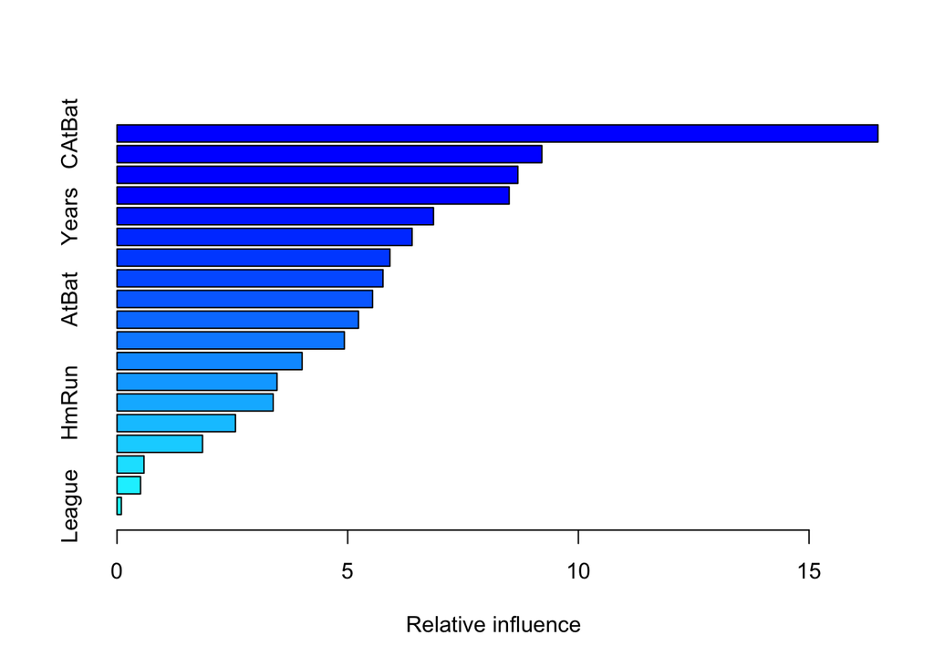

```
##                 var    rel.inf
## CAtBat       CAtBat 16.4925747
## CWalks       CWalks  9.2082058
## CHits         CHits  8.6886908
## CRBI           CRBI  8.4993702
## Years         Years  6.8592019
## PutOuts     PutOuts  6.3958037
## Walks         Walks  5.9156080
## CRuns         CRuns  5.7654334
## AtBat         AtBat  5.5396231
## CHmRun       CHmRun  5.2332733
## RBI             RBI  4.9275512
## Hits           Hits  4.0115338
## Assists     Assists  3.4678112
## HmRun         HmRun  3.3848208
## Errors       Errors  2.5669344
## Runs           Runs  1.8534787
## NewLeague NewLeague  0.5856062
## Division   Division  0.5105495
## League       League  0.0939290
```

```r
summary(gbm_list[[which.min(test_mses)]])
```

`CAtBat` appears to be the most important variable, followed by `CWalks`, `CHits` and `CRBI`.

**Now apply bagging to the training set. What is the test set MSE for this approach?**

```r
m <- ncol(hitters) - 1
bag_fit <- randomForest(Salary ~ ., data = train, mtry = m)
sprintf("Bagging test MSE: %s", mean((predict(bag_fit, test) - test$Salary) ^ 2))
```

```
## [1] "Bagging test MSE: 0.22973629967915"
```

Bagging slightly outperforms boosting on test MSE.

## Exercise 11

**This question uses the `Caravan` data set.**

**Create a training set consisting of the first 1,000 observations, and a test set consisting of the remaining observations.**

```r
train <- Caravan[1:1000,]
test <- Caravan[-c(1:1000),]
```

**Fit a boosting model to the training set with `Purchase` as the response and the other variables as predictors. Use 1,000 trees, and a shrinkage value of 0.01. Which predictors appear to be the most important?**

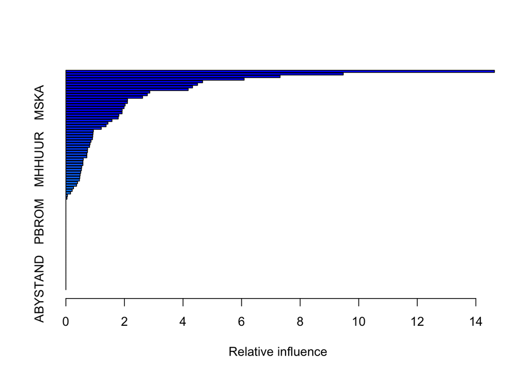

```
##               var     rel.inf
## PPERSAUT PPERSAUT 14.63504779
## MKOOPKLA MKOOPKLA  9.47091649
## MOPLHOOG MOPLHOOG  7.31457416
## MBERMIDD MBERMIDD  6.08651965
## PBRAND     PBRAND  4.66766122
## MGODGE     MGODGE  4.49463264
## ABRAND     ABRAND  4.32427755
## MINK3045 MINK3045  4.17590619
## MOSTYPE   MOSTYPE  2.86402583
## PWAPART   PWAPART  2.78191075
## MAUT1       MAUT1  2.61929152
## MBERARBG MBERARBG  2.10480508
## MSKA         MSKA  2.10185152
## MAUT2       MAUT2  2.02172510
## MSKC         MSKC  1.98684345
## MINKGEM   MINKGEM  1.92122708
## MGODPR     MGODPR  1.91777542
## MBERHOOG MBERHOOG  1.80710618
## MGODOV     MGODOV  1.78693913
## PBYSTAND PBYSTAND  1.57279593
## MSKB1       MSKB1  1.43551401
## MFWEKIND MFWEKIND  1.37264255
## MRELGE     MRELGE  1.20805179
## MOPLMIDD MOPLMIDD  0.93791970
## MINK7512 MINK7512  0.92590720
## MINK4575 MINK4575  0.91745993
## MGODRK     MGODRK  0.90765539
## MFGEKIND MFGEKIND  0.85745374
## MZPART     MZPART  0.82531066
## MRELOV     MRELOV  0.80731252
## MINKM30   MINKM30  0.74126812
## MHKOOP     MHKOOP  0.73690793
## MZFONDS   MZFONDS  0.71638323
## MAUT0       MAUT0  0.71388052
## MHHUUR     MHHUUR  0.59287247
## APERSAUT APERSAUT  0.58056986
## MOSHOOFD MOSHOOFD  0.58029563
## MSKB2       MSKB2  0.53885275
## PLEVEN     PLEVEN  0.53052444
```

[output cut: 31 more lines]

```
## AMOTSCO   AMOTSCO  0.00000000
## AVRAAUT   AVRAAUT  0.00000000
## AAANHANG AAANHANG  0.00000000
## ATRACTOR ATRACTOR  0.00000000
## AWERKT     AWERKT  0.00000000
## ABROM       ABROM  0.00000000
## ALEVEN     ALEVEN  0.00000000
## APERSONG APERSONG  0.00000000
## AGEZONG   AGEZONG  0.00000000
## AWAOREG   AWAOREG  0.00000000
## AZEILPL   AZEILPL  0.00000000
## APLEZIER APLEZIER  0.00000000
## AFIETS     AFIETS  0.00000000
## AINBOED   AINBOED  0.00000000
## ABYSTAND ABYSTAND  0.00000000
```

```r
set.seed(1)
train$Purchase <- ifelse(train$Purchase == "Yes", 1, 0)
test$Purchase <- ifelse(test$Purchase == "Yes", 1, 0)
gbm_train <- gbm(Purchase ~ ., data = train, distribution = "bernoulli", n.trees = 1000, shrinkage = 0.01)
summary(gbm_train)
```

`PPERSAUT` is the most important predictor, followed by `MKOOPKLA` and `MOPLHOOG`.

**Use the boosting model to predict the response on the test data. Predict that a person will make a purchase if the estimated probability of purchase is greater than 20%. Form a confusion matrix. What fraction of the people predicted to make a purchase do in fact make one? How does this compare with the results obtained from applying KNN or logistic regression to this data set?**

```r
gbm_probs <- predict(gbm_train, test, type = "response")
```

```
## Using 1000 trees...
```

```r
gbm_preds <- ifelse(gbm_probs > 0.2, "Yes", "No")
test_purchase <- ifelse(test$Purchase == 1, "Yes", "No")
table(gbm_preds, test_purchase)
```

```
##          test_purchase
## gbm_preds   No  Yes
##       No  4410  256
##       Yes  123   33
```

```r
mean(gbm_preds[gbm_preds == "Yes"] == test_purchase[gbm_preds == "Yes"])
```

```
## [1] 0.2115385
```

The proportion of predicted purchases who actually purchase is 21.15%.

Comparing to KNN using `k = 4`:

```r
knn_caravan <- knn(train[, which(names(train) != "Purchase")],
                   test[, which(names(train) != "Purchase")],
                   train$Purchase,
                   k = 4)
levels(knn_caravan) <- c("No", "Yes")
table(knn_caravan, test_purchase)
```

```
##            test_purchase
## knn_caravan   No  Yes
##         No  4466  279
##         Yes   67   10
```

```r
mean(knn_caravan[knn_caravan == "Yes"] == test_purchase[knn_caravan == "Yes"])
```

```
## [1] 0.1298701
```

KNN does not perform as well as boosting in terms of predicted purchases actually being purchases.

## Exercise 12

**Apply boosting, bagging, and random forests to a data set of your choice. Be sure to fit the models on a training set and to evaluate their performance on a test set. How accurate are the results compared to simple methods like linear or logistic regression? Which of these approaches yields the best performance?**

```r
set.seed(1)

# Train/test split
smarket <- Smarket[, which(names(Smarket) != "Today")]
train <- sample(seq_len(nrow(smarket)), 0.7 * nrow(smarket))

# Random forest
rf_smarket <- randomForest(x = smarket[train, which(names(smarket) != "Direction")],
                           y = smarket[train, "Direction"],
                           xtest = smarket[-train, which(names(smarket) != "Direction")],
                           ytest = smarket[-train, "Direction"])
sprintf("Random forest accuracy: %s", mean(rf_smarket$test$predicted == smarket[-train, "Direction"]))
```

```
## [1] "Random forest accuracy: 0.509333333333333"
```

```r
# Bagging
bag_smarket <- randomForest(x = smarket[train, which(names(smarket) != "Direction")],
                            y = smarket[train, "Direction"],
                            xtest = smarket[-train, which(names(smarket) != "Direction")],
                            ytest = smarket[-train, "Direction"],
                            mtry = ncol(smarket) - 1)
sprintf("Bagging  accuracy: %s", mean(bag_smarket$test$predicted == smarket[-train, "Direction"]))
```

```
## [1] "Bagging  accuracy: 0.514666666666667"
```

```r
# Boosting
train_data <- smarket[train,]
train_data$Direction <- ifelse(train_data$Direction == "Up", 1, 0)
boost_smarket <- gbm(Direction ~ ., data = train_data, distribution = "bernoulli")
boost_preds <- predict(boost_smarket, smarket[-train,], type = "response")
```

```
## Using 100 trees...
```

```r
boost_pred_class <- ifelse(boost_preds > 0.5, "Up", "Down")
sprintf("Boosting accuracy: %s", mean(boost_pred_class == smarket[-train, "Direction"]))
```

```
## [1] "Boosting accuracy: 0.536"
```

```r
# Logistic regression
logistic_reg <- glm(Direction ~ ., data = smarket[train,], family = "binomial")
logistic_preds <- predict(logistic_reg, smarket[-train,], type = "response")
logistic_pred_class <- ifelse(logistic_preds > 0.5, "Up", "Down")
sprintf("Logistic regression accuracy: %s", mean(logistic_pred_class == smarket[-train, "Direction"]))
```

```
## [1] "Logistic regression accuracy: 0.512"
```

Boosting gives the highest test set accuracy. Logistic regression outperforms random forests, but not bagging.